# 10 Discrete IVs and Other

```r
sink <- lm(wage96~ male+ norcen96+west96+south96+ black + hispanic, data=hw)
summary(sink)
```

```
##
## Call:
## lm(formula = wage96 ~ male + norcen96 + west96 + south96 + black +
##     hispanic, data = hw)
##
## Residuals:
##     Min      1Q  Median      3Q     Max
##  -18.81   -6.94   -3.11    2.06 1522.02
##
## Coefficients:
##             Estimate Std. Error t value Pr(>|t|)
## (Intercept)  17.5477     0.9399  18.671  < 2e-16 ***
## male          1.2627     0.6611   1.910  0.05617 .
## norcen96     -3.1336     1.0690  -2.931  0.00339 **
## west96       -1.4993     1.1364  -1.319  0.18710
## south96      -4.1520     0.9820  -4.228 2.39e-05 ***
## black        -3.1006     0.7921  -3.914 9.15e-05 ***
## hispanic     -2.5418     0.9387  -2.708  0.00679 **
## ---
## Signif. codes:  0 '***' 0.001 '**' 0.01 '*' 0.05 '.' 0.1 ' ' 1
##
## Residual standard error: 27.32 on 6857 degrees of freedom
##   (5822 observations deleted due to missingness)
## Multiple R-squared:  0.007076,   Adjusted R-squared:  0.006207
## F-statistic: 8.144 on 6 and 6857 DF,  p-value: 8.541e-09
```

Summarizing regression models

```r
#Yesterday we used model summary, today we will use stargazer to create nice regression tables
library("stargazer")
stargazer(ck1a,reg3, sink, type="text", title = "Multivariate Regression Models")
```

```
##
## Multivariate Regression Models
## ===========================================================================================
##                                               Dependent variable:
##                     -----------------------------------------------------------------------
##                                                     wage96
##                              (1)                     (2)                      (3)
## -------------------------------------------------------------------------------------------
## male                       1.519**                                          1.263*
##                            (0.658)                                          (0.661)
##
## hgc96                                              1.636***
##                                                    (0.135)
##
## norest96                                           3.975***
##                                                    (0.965)
##
## norcen96                                            1.617*                 -3.134***
##                                                    (0.843)                  (1.069)
##
## west96                                             2.740***                 -1.499
##                                                    (0.901)                  (1.136)
##
## south96                                                                    -4.152***
##                                                                             (0.982)
##
## black                                                                      -3.101***
##                                                                             (0.792)
##
## hispanic                                                                   -2.542***
##                                                                             (0.939)
##
## Constant                  13.376***               -9.073***                17.548***
##                            (0.478)                 (1.846)                  (0.940)
##
## -------------------------------------------------------------------------------------------
## Observations                6,930                   6,862                    6,864
## R2                          0.001                   0.025                    0.007
## Adjusted R2                 0.001                   0.024                    0.006
## Residual Std. Error   27.363 (df = 6928)      27.080 (df = 6857)      27.323 (df = 6857)
## F Statistic         5.320** (df = 1; 6928) 43.326*** (df = 4; 6857) 8.144*** (df = 6; 6857)
## ===========================================================================================
## Note:                                                           *p<0.1; **p<0.05; ***p<0.01
```

```
## `height` was translated to `width`.
## `height` was translated to `width`.
```

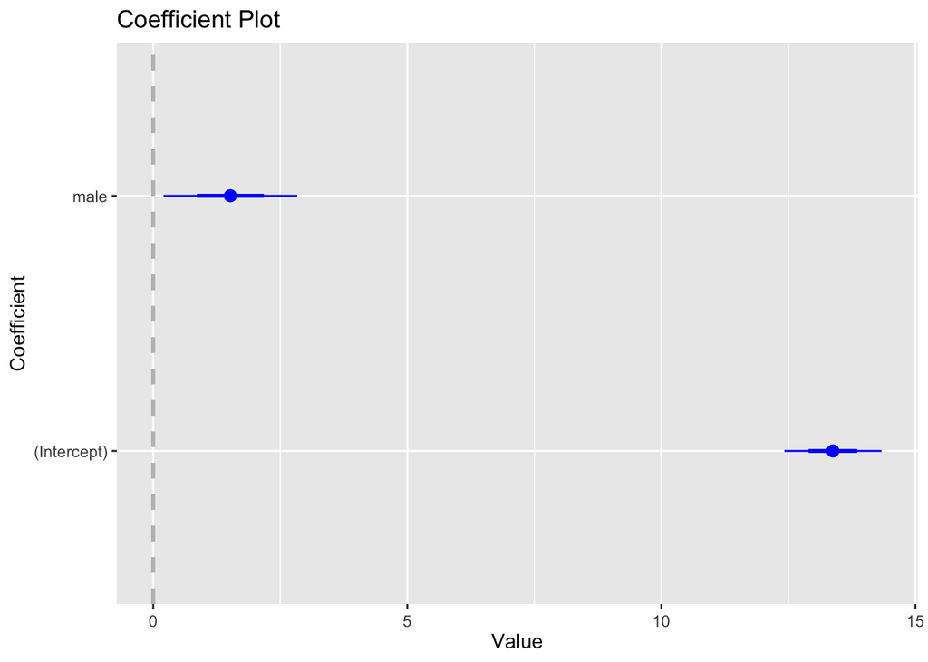

```r
#We can also use the coefplot package.
library(coefplot)#New Package. Will need to install. Also makes coefficient plots

coefplot(ck1a)#point is equal to coefficient. Lines are confidence interval. When CI does not overlap 0 coefficient is significant
```

```
## `height` was translated to `width`.
## `height` was translated to `width`.
```

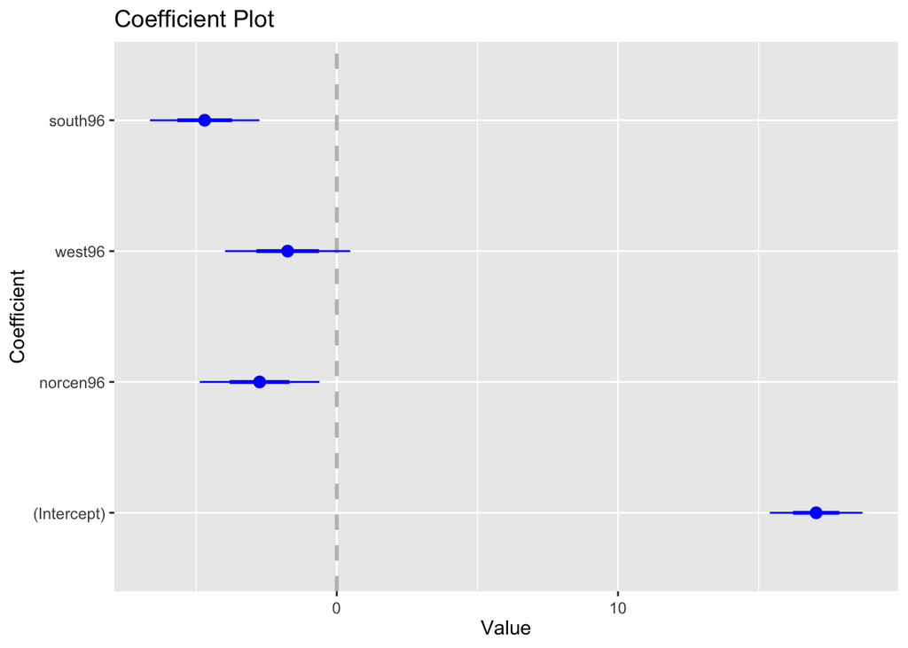

```r
coefplot(reg2)
```

```
## `height` was translated to `width`.
## `height` was translated to `width`.
```

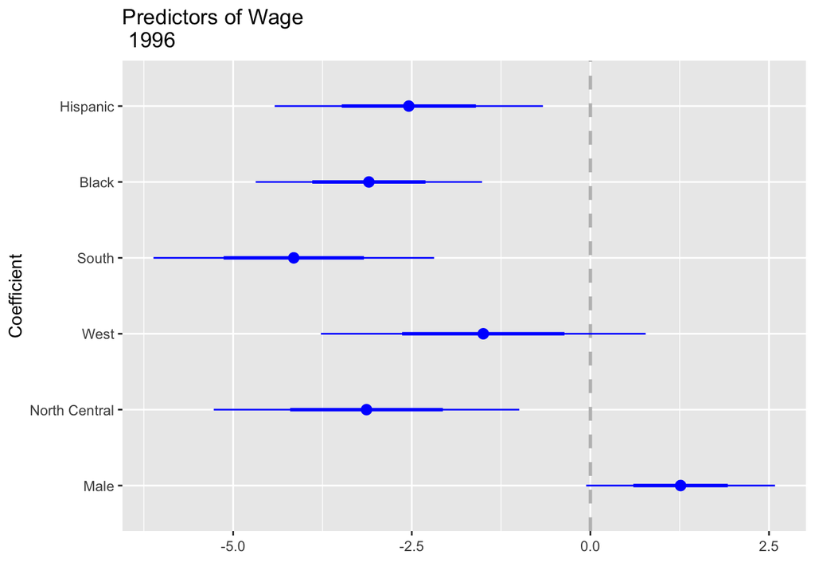

```r
coefplot(sink, intercept = FALSE, newNames=c(hispanic="Hispanic", black="Black", south96="South", west96="West", norcen96="North Central", male="Male"), title="Predictors of Wage \n 1996", xlab="")
```

```
## `height` was translated to `width`.
## `height` was translated to `width`.
```

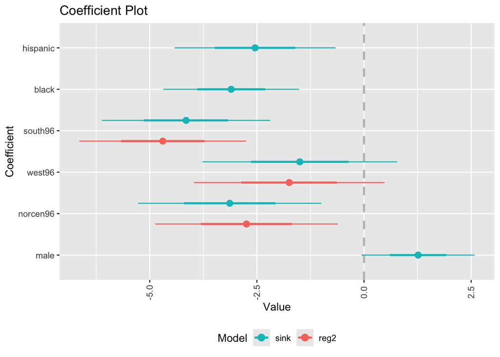

```r
multiplot(sink, reg2, intercept=FALSE)
```

```
## `height` was translated to `width`.
## `height` was translated to `width`.
```

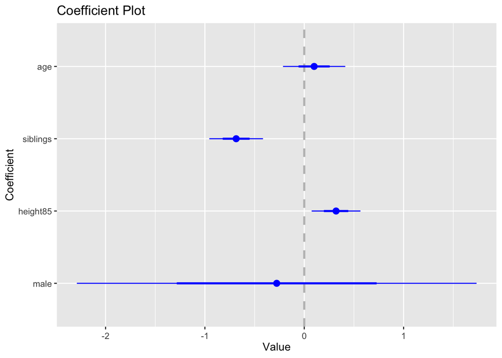

```r
coefplot(ck2, intercept = FALSE)#remember comparing size of effect only makes sense when range is the same.
```

Bonus: Based on your extensive knowledge of American wages and statistics create your version of the best regression model(or models) Double Bonus: Create a table using stargazer

Lets play a bit more with regression assumptions and transforming variables

```r
# Restrict to employed respondents with complete height data
hwdata2 <- subset(hw, !is.na(wage96) & wage96 > 0 & !is.na(height85))

hwdata2$lwage <- log(hwdata2$wage96)   # log hourly wage
```

## Why Log Wages?

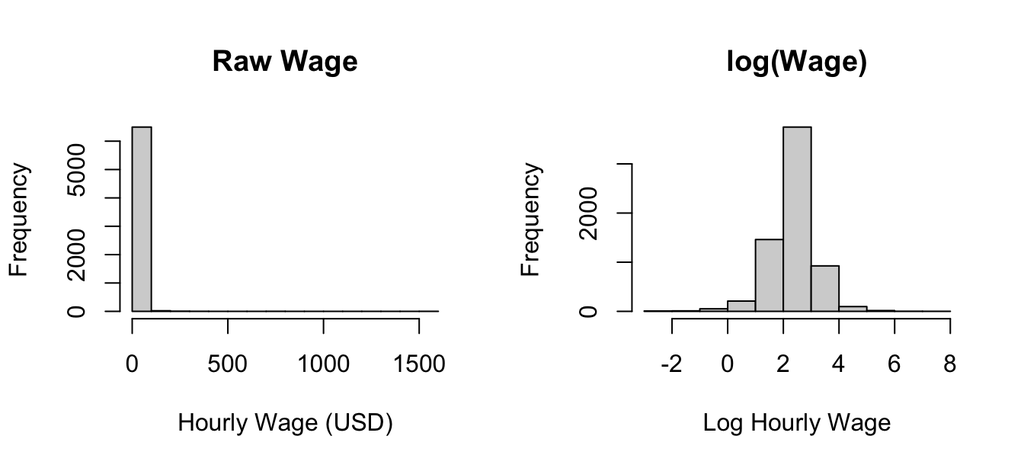

```r
par(mfrow = c(1, 2))
hist(hwdata2$wage96, main = "Raw Wage",      xlab = "Hourly Wage (USD)")
hist(hwdata2$lwage,  main = "log(Wage)",     xlab = "Log Hourly Wage")
```

- Raw wages are **right-skewed** — a few very high earners pull the tail
- Log transformation compresses the scale and produces an approximately normal distribution
- Interpretation shifts: a 1-inch increase in height is associated with a **percentage change** in wages

## Scatter Plot: Height and Log Wages

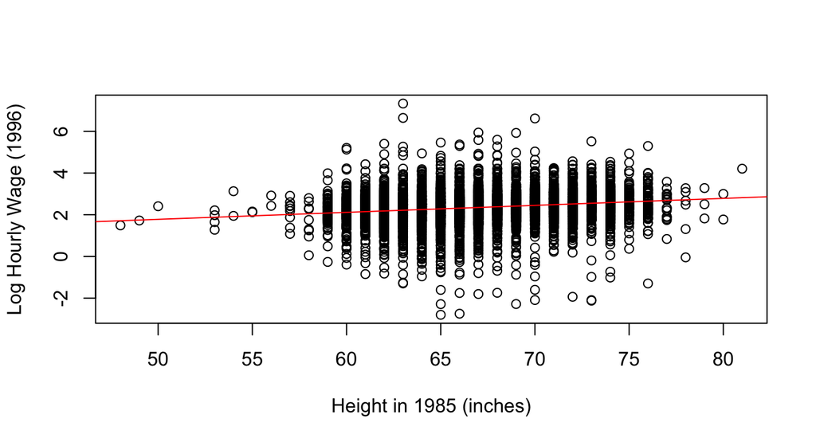

```r
plot(hwdata2$lwage ~ hwdata2$height85,
     xlab = "Height in 1985 (inches)",
     ylab = "Log Hourly Wage (1996)")

abline(lm(lwage ~ height85, data = hwdata2), col = "red")
```

- Is there a positive relationship? Does it look roughly linear?
- Outliers at the extremes are worth noting

## Compare: Logged vs. Unlogged Outcome

```r
model.wage.orig <- lm(wage96 ~ height85, data = hwdata2)
model.wage      <- lm(lwage  ~ height85, data = hwdata2)

modelsummary(
  list("Original" = model.wage.orig, "Log Outcome" = model.wage),
  stars  = c("*" = .1, "**" = .05, "***" = .01),
  output = "kableExtra"
)
```

|  | Original | Log Outcome |
| --- | --- | --- |
| (Intercept) | −7.283 | 0.102 |
|  | (5.708) | (0.156) |
| height85 | 0.325*** | 0.034*** |
|  | (0.085) | (0.002) |
| Num.Obs. | 6529 | 6529 |
| R2 | 0.002 | 0.031 |
| R2 Adj. | 0.002 | 0.031 |
| AIC | 62025.5 | 15035.5 |
| BIC | 62045.8 | 15055.8 |
| Log.Lik. | −31009.725 | −7514.744 |
| F | 14.782 | 210.150 |
| RMSE | 27.96 | 0.76 |

* p < 0.1, ** p < 0.05, *** p < 0.01

- Compare $R^2$, residual standard error, and residual patterns
- Logged model: coefficient interpreted as *“a 1-inch increase in height is associated with a* $\hat{\beta} \times 100\%$ change in wages”

# Regression Diagnostics

## The Four Diagnostic Plots

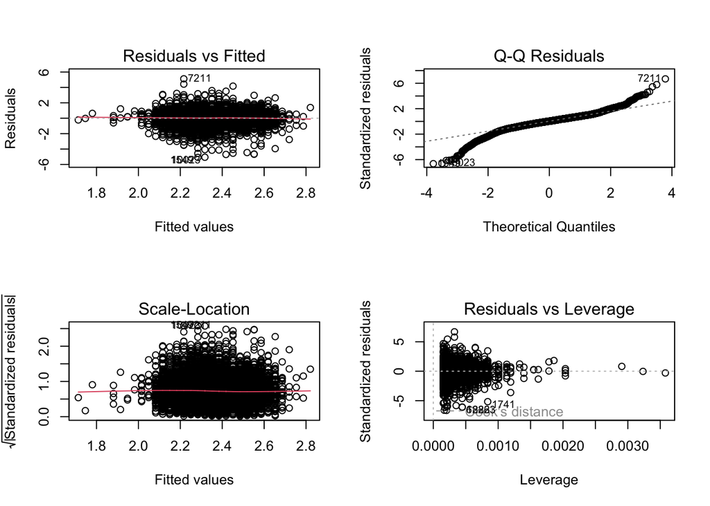

```r
par(mfrow = c(2, 2))
plot(model.wage, labels.id = rownames(hwdata2))
```

Four plots, four questions:

1. **Residuals vs. Fitted** — is the relationship linear? Should hug the dashed line
2. **Normal Q-Q** — are errors normally distributed? Points should follow the diagonal
3. **Scale-Location** — is variance constant (homoskedasticity)? Should be flat, no V-shape
4. **Residuals vs. Leverage** — are any observations disproportionately influential? (Cook’s distance)

## Reading Each Plot

**Residuals vs. Fitted**

- Curve or U-shape → **non-linearity** (try a transformation)
- Fan shape → **heteroskedasticity** (use robust SE)
- Should be random scatter around zero

**Residuals vs. Leverage**

- Points outside Cook’s distance contour are **high-influence**
- High leverage $\neq$ bad, but worth inspecting
- Ask: does the result change substantially if I drop this case?

## Removing Outliers — With Caution

```r
# Identify high-wage outliers (e.g., top 1%)
wage_cutoff <- quantile(hwdata2$wage96, 0.99, na.rm = TRUE)#fance way to take out outleirs
hwdata4 <- subset(hwdata2, wage96 < wage_cutoff)

model2.wage <- lm(lwage ~ height85, data = hwdata4)
summary(model2.wage)
```

```
##
## Call:
## lm(formula = lwage ~ height85, data = hwdata4)
##
## Residuals:
##     Min      1Q  Median      3Q     Max
## -5.0566 -0.3589  0.0508  0.4435  2.0753
##
## Coefficients:
##             Estimate Std. Error t value Pr(>|t|)
## (Intercept) 0.069746   0.148190   0.471    0.638
## height85    0.033639   0.002197  15.314   <2e-16 ***
## ---
## Signif. codes:  0 '***' 0.001 '**' 0.01 '*' 0.05 '.' 0.1 ' ' 1
##
## Residual standard error: 0.722 on 6453 degrees of freedom
## Multiple R-squared:  0.03507,    Adjusted R-squared:  0.03492
## F-statistic: 234.5 on 1 and 6453 DF,  p-value: < 2.2e-16
```

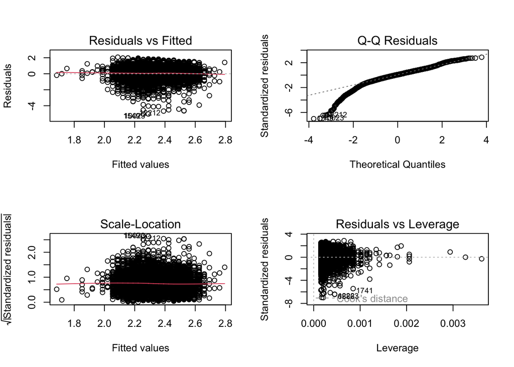

```r
par(mfrow = c(2, 2))
plot(model2.wage, labels.id = rownames(hwdata4))
```

**Warning:** Only remove observations if you have a **substantive theoretical reason**. Removing outliers to improve fit is data manipulation. Here we may want to keep high earners — they are real data points.

# Part 3: Multicollinearity

## A Richer Model

```r
# Predict log wages with height plus controls
model6 <- lm(lwage ~ height85 + hgc96 + male + daded79 + momed79,
             data = hwdata2)
modelsummary(model6)
```

|  | (1) |
| --- | --- |
| (Intercept) | -0.021 |
|  | (0.220) |
| height85 | 0.012 |
|  | (0.003) |
| hgc96 | 0.098 |
|  | (0.004) |
| male | 0.193 |
|  | (0.028) |
| daded79 | 0.017 |
|  | (0.003) |
| momed79 | 0.000 |
|  | (0.004) |
| Num.Obs. | 5483 |
| R2 | 0.155 |
| R2 Adj. | 0.154 |
| AIC | 11801.5 |
| BIC | 11847.8 |
| Log.Lik. | -5893.743 |
| F | 201.073 |
| RMSE | 0.71 |

- Unit of analysis: **individual respondent**
- Are father’s education (`daded79`) and mother’s education (`momed79`) correlated with each other?

## The Problem: Correlated Predictors

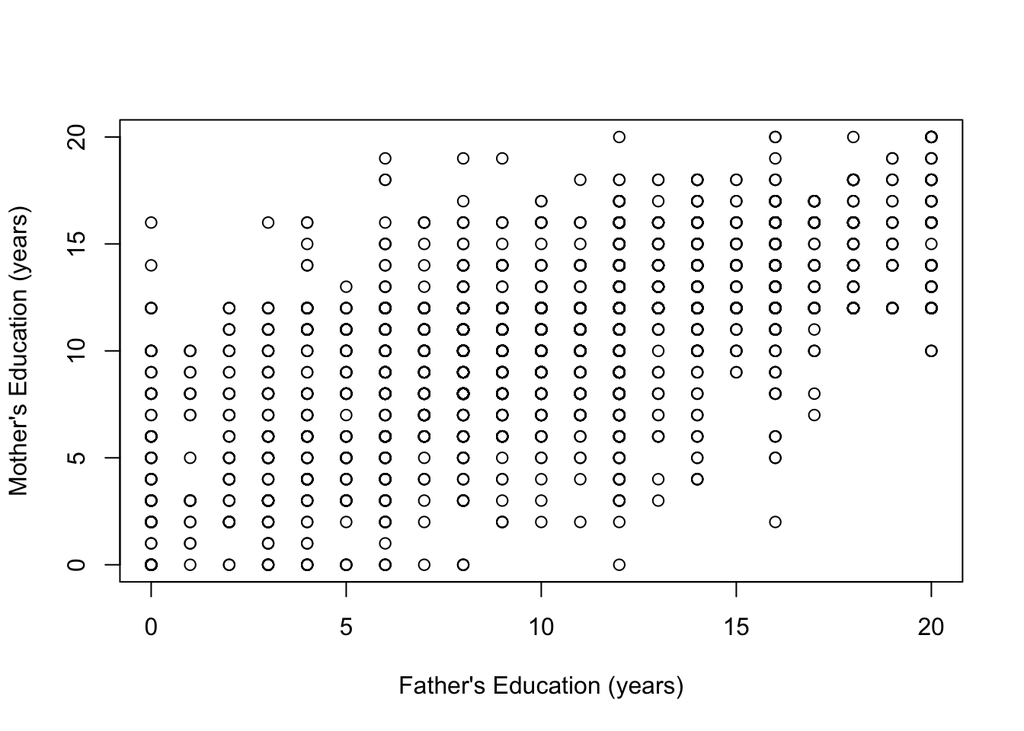

```r
par(mfrow = c(1, 1)) #back to one pane
plot(hwdata2$daded79, hwdata2$momed79,
     xlab = "Father's Education (years)",
     ylab = "Mother's Education (years)")
```

```r
cor(hwdata2$daded79, hwdata2$momed79, use = "complete")
```

```
## [1] 0.6583598
```

- Parents’ education levels tend to be correlated — assortative mating
- Putting both in the same model asks OLS to separate effects it cannot easily distinguish

## Fit the Model and Check VIF

```r
library(car)
vif(model6)
```

```
## height85    hgc96     male  daded79  momed79
## 2.166372 1.232115 2.116669 1.836237 1.861024
```

- VIF $>$ 5: warrants inspection
- VIF $>$ 10: serious problem — coefficients are unreliable
- Note how individual coefficients may be insignificant even when the overall model fits well

## Inspect the Diagnostics

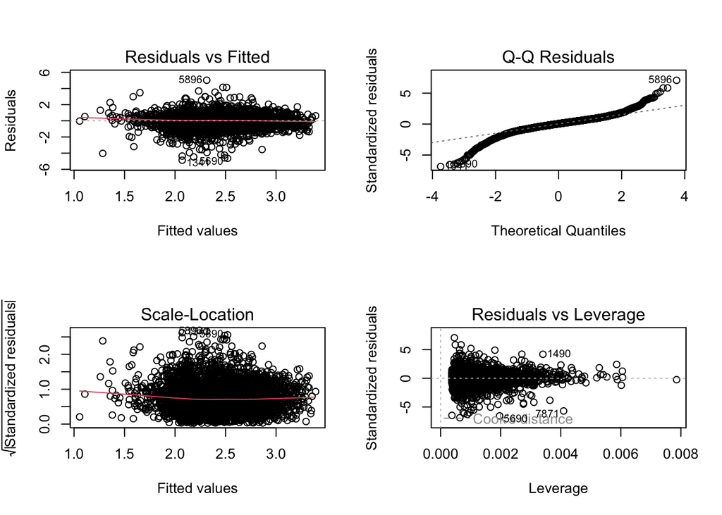

```r
par(mfrow = c(2, 2))
plot(model6, labels.id = rownames(hwdata2))
```

Also compare single-predictor models to the joint model:

```r
summary(lm(lwage ~ daded79, data = hwdata2))
```

```
##
## Call:
## lm(formula = lwage ~ daded79, data = hwdata2)
##
## Residuals:
##     Min      1Q  Median      3Q     Max
## -5.0589 -0.3746  0.0480  0.4198  4.9039
##
## Coefficients:
##             Estimate Std. Error t value Pr(>|t|)
## (Intercept) 1.912970   0.030149   63.45   <2e-16 ***
## daded79     0.043197   0.002564   16.85   <2e-16 ***
## ---
## Signif. codes:  0 '***' 0.001 '**' 0.01 '*' 0.05 '.' 0.1 ' ' 1
##
## Residual standard error: 0.7547 on 5657 degrees of freedom
##   (870 observations deleted due to missingness)
## Multiple R-squared:  0.04778,    Adjusted R-squared:  0.04761
## F-statistic: 283.8 on 1 and 5657 DF,  p-value: < 2.2e-16
```

```r
summary(lm(lwage ~ momed79, data = hwdata2))
```

```
##
## Call:
## lm(formula = lwage ~ momed79, data = hwdata2)
##
## Residuals:
##     Min      1Q  Median      3Q     Max
## -5.1732 -0.3791  0.0466  0.4284  4.9159
##
## Coefficients:
##             Estimate Std. Error t value Pr(>|t|)
## (Intercept) 1.861677   0.034598   53.81   <2e-16 ***
## momed79     0.046469   0.003035   15.31   <2e-16 ***
## ---
## Signif. codes:  0 '***' 0.001 '**' 0.01 '*' 0.05 '.' 0.1 ' ' 1
##
## Residual standard error: 0.7611 on 6154 degrees of freedom
##   (373 observations deleted due to missingness)
## Multiple R-squared:  0.03671,    Adjusted R-squared:  0.03655
## F-statistic: 234.5 on 1 and 6154 DF,  p-value: < 2.2e-16
```

If each predictor is significant alone but not together, that is a classic **multicollinearity signature.**

# All-in-one Regression Diagnostic package

```r
model9 <- lm(lwage ~ height85 + hgc96 + male +
               daded79 + momed79 + esteem80,
             data = hwdata2)


# install.packages("gvlma")
library(gvlma)

model9 <- lm(lwage ~ height85 + hgc96 + male +
               daded79 + momed79 + esteem80,
             data = hwdata2)

summary(gvlma(model9))
```

```
##
## Call:
## lm(formula = lwage ~ height85 + hgc96 + male + daded79 + momed79 +
##     esteem80, data = hwdata2)
##
## Residuals:
##     Min      1Q  Median      3Q     Max
## -4.8628 -0.3363  0.0414  0.3826  5.0027
##
## Coefficients:
##              Estimate Std. Error t value Pr(>|t|)
## (Intercept) -0.343746   0.231673  -1.484  0.13793
## height85     0.010932   0.003479   3.142  0.00169 **
## hgc96        0.091878   0.004517  20.340  < 2e-16 ***
## male         0.199807   0.028064   7.120 1.22e-12 ***
## daded79      0.017158   0.003351   5.120 3.16e-07 ***
## momed79     -0.001971   0.004193  -0.470  0.63829
## esteem80     0.020761   0.003660   5.673 1.48e-08 ***
## ---
## Signif. codes:  0 '***' 0.001 '**' 0.01 '*' 0.05 '.' 0.1 ' ' 1
##
## Residual standard error: 0.7058 on 5352 degrees of freedom
##   (1170 observations deleted due to missingness)
## Multiple R-squared:  0.1588, Adjusted R-squared:  0.1578
## F-statistic: 168.4 on 6 and 5352 DF,  p-value: < 2.2e-16
##
##
## ASSESSMENT OF THE LINEAR MODEL ASSUMPTIONS
## USING THE GLOBAL TEST ON 4 DEGREES-OF-FREEDOM:
## Level of Significance =  0.05
##
## Call:
##  gvlma(x = model9)
##
##                        Value p-value                   Decision
## Global Stat        7657.0402 0.00000 Assumptions NOT satisfied!
## Skewness            286.6201 0.00000 Assumptions NOT satisfied!
## Kurtosis           7365.8313 0.00000 Assumptions NOT satisfied!
## Link Function         0.1907 0.66230    Assumptions acceptable.
## Heteroscedasticity    4.3981 0.03598 Assumptions NOT satisfied!
```

| Test | Null hypothesis ($H_0$) |
| --- | --- |
| Global Stat | Relationship is linear |
| Skewness | Errors are not skewed |
| Kurtosis | Errors are not kurtotic |
| Link Function | DV is continuous (not categorical) |
| Heteroscedasticity | Residual variance is constant |

Reject ($p < .05$) = assumption violated.

## `performance` — Modern Alternative

# install.packages(“performance”)

```r
library(performance)

check_autocorrelation(model9)
check_normality(model9)
check_collinearity(model9)
```

```
## # Check for Multicollinearity
##
## Low Correlation
##
##      Term  VIF   VIF 95% CI adj. VIF Tolerance Tolerance 95% CI
##  height85 2.16 [2.08, 2.26]     1.47      0.46     [0.44, 0.48]
##     hgc96 1.29 [1.25, 1.33]     1.13      0.78     [0.75, 0.80]
##      male 2.11 [2.03, 2.20]     1.45      0.47     [0.45, 0.49]
##   daded79 1.84 [1.77, 1.92]     1.36      0.54     [0.52, 0.56]
##   momed79 1.87 [1.80, 1.94]     1.37      0.54     [0.51, 0.56]
##  esteem80 1.10 [1.07, 1.13]     1.05      0.91     [0.88, 0.94]
```

```r
check_heteroskedasticity(model9)
model_performance(model9)
```

```
## # Indices of model performance
##
## AIC     |    AICc |     BIC |    R2 | R2 (adj.) |  RMSE | Sigma
## ---------------------------------------------------------------
## 11482.8 | 11482.9 | 11535.5 | 0.159 |     0.158 | 0.705 | 0.706
```

| Check | Tool |
| --- | --- |
| Right-skewed outcome or predictor? | `hist()` $\to$ log-transform |
| Non-linearity? | Residuals vs. Fitted plot |
| Heteroskedasticity? | Scale-Location plot; `bptest()` |
| Influential outliers? | Residuals vs. Leverage; Cook’s distance |
| Multicollinearity? | `cor()`; `vif()` |
| Autocorrelation? | `durbinWatsonTest()` |
| All at once? | `check_model()` or `summary(gvlma())` |

Remember: violating these assumptions does not always mean **bias** — it usually means your **standard errors are wrong**, which corrupts inference even when coefficients look reasonable.

# Experiments

Set working directory and unpack packages

```r
#install.packages("pwr")
#install.packages("AER")
library(haven)
library(tidyverse)
library(pwr)
library(AER)
#More info here: https://www.statmethods.net/stats/power.html
```

Recall, with experiments we’re focused more on design than statistical analysis.

#Practice data from the textbook.

```r
GGD <- read_csv("GerberGreenData.csv")
summary(GGD)
```

```
##     PeopleHH          Ward       ContactAssigned      Voted
##  Min.   :1.000   Min.   : 2.00   Min.   :0.0000   Min.   :0.0000
##  1st Qu.:1.000   1st Qu.:10.00   1st Qu.:0.0000   1st Qu.:0.0000
##  Median :1.000   Median :17.00   Median :0.0000   Median :0.0000
##  Mean   :1.497   Mean   :16.43   Mean   :0.1972   Mean   :0.4525
##  3rd Qu.:2.000   3rd Qu.:24.00   3rd Qu.:0.0000   3rd Qu.:1.0000
##  Max.   :2.000   Max.   :30.00   Max.   :1.0000   Max.   :1.0000
##  NAs    :1       NAs    :1       NAs    :1        NAs    :1
##  ContactObserved
##  Min.   :0.00000
##  1st Qu.:0.00000
##  Median :0.00000
##  Mean   :0.05497
##  3rd Qu.:0.00000
##  Max.   :1.00000
##
```

```r
#check balance across wards
b1 <- table(GGD$Ward, GGD$ContactAssigned)
prop.table(b1, 1) #Balance looks good.
```

```
##
##              0         1
##   2  0.8016148 0.1983852
##   3  0.8619120 0.1380880
##   4  0.8193146 0.1806854
##   5  0.8094406 0.1905594
##   6  0.8006873 0.1993127
##   7  0.8047404 0.1952596
##   8  0.7810362 0.2189638
##   9  0.7970123 0.2029877
##   10 0.8086614 0.1913386
##   11 0.7965839 0.2034161
##   12 0.7794643 0.2205357
##   13 0.8108327 0.1891673
##   14 0.8070352 0.1929648
```

[output cut: 16 more lines]

```r
summary(lm(GGD$ContactAssigned~GGD$Ward)) # Can run T-test or regression to see if sig dif. Ward is not correlated with treatment assignment
```

```
##
## Call:
## lm(formula = GGD$ContactAssigned ~ GGD$Ward)
##
## Residuals:
##     Min      1Q  Median      3Q     Max
## -0.1973 -0.1972 -0.1972 -0.1971  0.8029
##
## Coefficients:
##              Estimate Std. Error t value Pr(>|t|)
## (Intercept) 1.971e-01  5.285e-03  37.293   <2e-16 ***
## GGD$Ward    6.431e-06  2.890e-04   0.022    0.982
## ---
## Signif. codes:  0 '***' 0.001 '**' 0.01 '*' 0.05 '.' 0.1 ' ' 1
##
## Residual standard error: 0.3979 on 29378 degrees of freedom
##   (1 observation deleted due to missingness)
## Multiple R-squared:  1.686e-08,  Adjusted R-squared:  -3.402e-05
## F-statistic: 0.0004952 on 1 and 29378 DF,  p-value: 0.9822
```

```r
#across # of people in household
b2 <- table(GGD$PeopleHH, GGD$ContactAssigned)
prop.table(b2, 1)
```

```
##
##             0         1
##   1 0.7999188 0.2000812
##   2 0.8056963 0.1943037
```

```r
#use dplyr
balance <- GGD %>% group_by(ContactAssigned)%>% summarise(People=mean(PeopleHH), Ward=mean(Ward))
t(balance)
```

```
##                     [,1]      [,2] [,3]
## ContactAssigned  0.00000  1.000000   NA
## People           1.49894  1.489817   NA
## Ward            16.43110 16.433725   NA
```

```r
#Experimental results: Does talking to people increase likelihood of voting?

#ITT does being assigned to treatment actually effect the likilood of voting(regardless of compliance)?
ITT <-(lm(GGD$Voted~GGD$ContactAssigned))
summary(ITT)
```

```
##
## Call:
## lm(formula = GGD$Voted ~ GGD$ContactAssigned)
##
## Residuals:
##     Min      1Q  Median      3Q     Max
## -0.4720 -0.4477 -0.4477  0.5523  0.5523
##
## Coefficients:
##                     Estimate Std. Error t value Pr(>|t|)
## (Intercept)         0.447681   0.003240 138.154  < 2e-16 ***
## GGD$ContactAssigned 0.024359   0.007297   3.338 0.000844 ***
## ---
## Signif. codes:  0 '***' 0.001 '**' 0.01 '*' 0.05 '.' 0.1 ' ' 1
##
## Residual standard error: 0.4977 on 29378 degrees of freedom
##   (1 observation deleted due to missingness)
## Multiple R-squared:  0.0003792,  Adjusted R-squared:  0.0003452
## F-statistic: 11.14 on 1 and 29378 DF,  p-value: 0.0008441
```

```r
#Voting is dummy variable and this is experimental. When we use OLS on a dummy we call it a linear probablity model and it is interpreted as percentage change in Y from a one unit change in X. An advanced class would talk about the advantages of LPM vs logit or probit for binary DVs.

#What variables are we missing from our model?

summary(lm(Voted ~ ContactAssigned+Ward+PeopleHH, data=GGD))#adding controls does not change coefficient, only signifigance
```

```
##
## Call:
## lm(formula = Voted ~ ContactAssigned + Ward + PeopleHH, data = GGD)
##
## Residuals:
##     Min      1Q  Median      3Q     Max
## -0.5742 -0.4492 -0.3618  0.5205  0.6565
##
## Coefficients:
##                 Estimate Std. Error t value Pr(>|t|)
## (Intercept)     0.233020   0.010453  22.292  < 2e-16 ***
## ContactAssigned 0.025291   0.007240   3.493 0.000478 ***
## Ward            0.003655   0.000361  10.125  < 2e-16 ***
## PeopleHH        0.103146   0.005800  17.784  < 2e-16 ***
## ---
## Signif. codes:  0 '***' 0.001 '**' 0.01 '*' 0.05 '.' 0.1 ' ' 1
##
## Residual standard error: 0.4938 on 29376 degrees of freedom
##   (1 observation deleted due to missingness)
## Multiple R-squared:  0.016,  Adjusted R-squared:  0.0159
## F-statistic: 159.2 on 3 and 29376 DF,  p-value: < 2.2e-16
```

```r
#Compliance:

#ATE model
ATE <-(lm(GGD$Voted~GGD$ContactObserved)) #The effect of actually being treated
summary(ATE)
```

```
##
## Call:
## lm(formula = GGD$Voted ~ GGD$ContactObserved)
##
## Residuals:
##     Min      1Q  Median      3Q     Max
## -0.5901 -0.4445 -0.4445  0.5555  0.5555
##
## Coefficients:
##                     Estimate Std. Error t value Pr(>|t|)
## (Intercept)         0.444480   0.002981  149.13   <2e-16 ***
## GGD$ContactObserved 0.145612   0.012713   11.45   <2e-16 ***
## ---
## Signif. codes:  0 '***' 0.001 '**' 0.01 '*' 0.05 '.' 0.1 ' ' 1
##
## Residual standard error: 0.4966 on 29378 degrees of freedom
##   (1 observation deleted due to missingness)
## Multiple R-squared:  0.004446,   Adjusted R-squared:  0.004412
## F-statistic: 131.2 on 1 and 29378 DF,  p-value: < 2.2e-16
```

```r
#percentage of those assigned to treatment actually treated
summary(lm(ContactObserved ~ ContactAssigned, data=GGD))#table 10.2 in book.
```

```
##
## Call:
## lm(formula = ContactObserved ~ ContactAssigned, data = GGD)
##
## Residuals:
##     Min      1Q  Median      3Q     Max
## -0.2787  0.0000  0.0000  0.0000  0.7213
##
## Coefficients:
##                   Estimate Std. Error t value Pr(>|t|)
## (Intercept)     -2.614e-14  1.297e-03    0.00        1
## ContactAssigned  2.787e-01  2.920e-03   95.47   <2e-16 ***
## ---
## Signif. codes:  0 '***' 0.001 '**' 0.01 '*' 0.05 '.' 0.1 ' ' 1
##
## Residual standard error: 0.1991 on 29378 degrees of freedom
##   (1 observation deleted due to missingness)
## Multiple R-squared:  0.2368, Adjusted R-squared:  0.2368
## F-statistic:  9114 on 1 and 29378 DF,  p-value: < 2.2e-16
```

```r
twosls <- ivreg(Voted ~ ContactObserved | ContactAssigned, data=GGD)
summary(twosls)
```

```
##
## Call:
## ivreg(formula = Voted ~ ContactObserved | ContactAssigned, data = GGD)
##
## Residuals:
##     Min      1Q  Median      3Q     Max
## -0.5351 -0.4477 -0.4477  0.5523  0.5523
##
## Coefficients:
##                 Estimate Std. Error t value Pr(>|t|)
## (Intercept)     0.447681   0.003235 138.386  < 2e-16 ***
## ContactObserved 0.087392   0.026135   3.344 0.000827 ***
## ---
## Signif. codes:  0 '***' 0.001 '**' 0.01 '*' 0.05 '.' 0.1 ' ' 1
##
## Residual standard error: 0.4968 on 29378 degrees of freedom
## Multiple R-Squared: 0.003735,    Adjusted R-squared: 0.003701
## Wald test: 11.18 on 1 and 29378 DF,  p-value: 0.0008272
```

```r
stargazer(ATE,ITT, twosls,  type="text", title = "Comparison of Experimental Models")
```

```
##
## Comparison of Experimental Models
## ==================================================================
##                                         Dependent variable:
##                                  ---------------------------------
##                                         Voted            Voted
##                                          OLS          instrumental
##                                                         variable
##                                     (1)        (2)        (3)
## ------------------------------------------------------------------
## ContactObserved                   0.146***
##                                   (0.013)
##
## ContactAssigned                             0.024***
##                                              (0.007)
##
## ContactObserved                                         0.087***
##                                                         (0.026)
##
## Constant                          0.444***  0.448***    0.448***
##                                   (0.003)    (0.003)    (0.003)
##
## ------------------------------------------------------------------
## Observations                       29,380    29,380      29,380
## R2                                 0.004     0.0004      0.004
## Adjusted R2                        0.004     0.0003      0.004
## Residual Std. Error (df = 29378)   0.497      0.498      0.497
## F Statistic (df = 1; 29378)      131.196*** 11.144***
## ==================================================================
## Note:                                  *p<0.1; **p<0.05; ***p<0.01
```

```
## `height` was translated to `width`.
## `height` was translated to `width`.
```

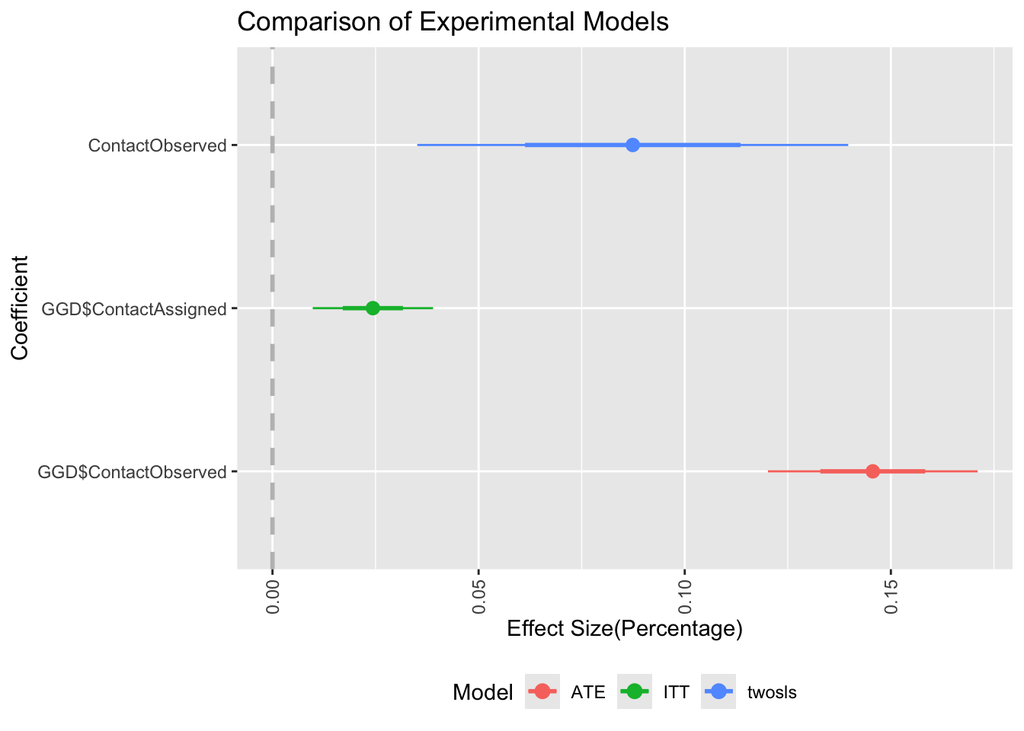

```r
multiplot(ATE,ITT, twosls, title = "Comparison of Experimental Models", xlab="Effect Size(Percentage)", intercept=FALSE)
```

Heterogeneous Treatment Effects

```r
#We have limited data, but say we were interested in if the effect of contact was dependent on the number of people in the household

hhe <- (lm(Voted~ContactObserved*PeopleHH, data=GGD))
summary(hhe)
```

```
##
## Call:
## lm(formula = Voted ~ ContactObserved * PeopleHH, data = GGD)
##
## Residuals:
##     Min      1Q  Median      3Q     Max
## -0.6317 -0.5003 -0.3894  0.4997  0.6106
##
## Coefficients:
##                           Estimate Std. Error t value Pr(>|t|)
## (Intercept)               0.278592   0.009349  29.800  < 2e-16 ***
## ContactObserved           0.184040   0.040132   4.586 4.54e-06 ***
## PeopleHH                  0.110849   0.005925  18.708  < 2e-16 ***
## ContactObserved:PeopleHH -0.026311   0.025274  -1.041    0.298
## ---
## Signif. codes:  0 '***' 0.001 '**' 0.01 '*' 0.05 '.' 0.1 ' ' 1
##
## Residual standard error: 0.4936 on 29376 degrees of freedom
##   (1 observation deleted due to missingness)
## Multiple R-squared:  0.01656,    Adjusted R-squared:  0.01646
## F-statistic: 164.9 on 3 and 29376 DF,  p-value: < 2.2e-16
```

I haven’t used it much, but DeclareDesign has good stuff on thinking through experimental designs (https://declaredesign.org/r/declaredesign/)